# Monte-Carlo Simulations and Analysis of Stochastic Differential Equations

A.C. Guidoum[^1] and K. Boukhetala[^2]

2020-11-07

# `snssde1d()`

Assume that we want to describe the following SDE:

Ito form[^3]:

$$\begin{equation}\label{eq:05}
dX_{t} = \frac{1}{2}\theta^{2} X_{t} dt + \theta X_{t} dW_{t},\qquad X_{0}=x_{0} > 0
\end{equation}$$

Stratonovich form:
$$\begin{equation}\label{eq:06}
dX_{t} = \frac{1}{2}\theta^{2} X_{t} dt +\theta X_{t} \circ dW_{t},\qquad X_{0}=x_{0} > 0
\end{equation}$$

In the above $f(t,x)=\frac{1}{2}\theta^{2} x$ and $g(t,x)= \theta x$ ($\theta > 0$), $W_{t}$ is a standard Wiener process. To simulate this models using `snssde1d()` function we need to specify:

- The `drift` and `diffusion` coefficients as R expressions that depend on the state variable `x` and time variable `t`.
- The number of simulation steps `N=1000` (by default: `N=1000`).
- The number of the solution trajectories to be simulated by `M=1000` (by default: `M=1`).
- The initial conditions `t0=0`, `x0=10` and end time `T=1` (by default: `t0=0`, `x0=0` and `T=1`).
- The integration step size `Dt=0.001` (by default: `Dt=(T-t0)/N`).
- The choice of process types by the argument `type="ito"` for Ito or `type="str"` for Stratonovich (by default `type="ito"`).
- The numerical method to be used by `method` (by default `method="euler"`).

```r
R> set.seed(1234, kind = "L'Ecuyer-CMRG")
R> theta = 0.5
R> f <- expression( (0.5*theta^2*x) )
R> g <- expression( theta*x )
R> mod1 <- snssde1d(drift=f,diffusion=g,x0=10,M=1000,type="ito") # Using Ito
R> mod2 <- snssde1d(drift=f,diffusion=g,x0=10,M=1000,type="str") # Using Stratonovich
R> mod1
```

```
Itô Sde 1D:
    | dX(t) = (0.5 * theta^2 * X(t)) * dt + theta * X(t) * dW(t)
Method:
    | Euler scheme with order 0.5
Summary:
    | Size of process   | N  = 1001.
    | Number of simulation  | M  = 1000.
    | Initial value     | x0 = 10.
    | Time of process   | t in [0,1].
    | Discretization    | Dt = 0.001.
```

```r
R> mod2
```

```
Stratonovich Sde 1D:
    | dX(t) = (0.5 * theta^2 * X(t)) * dt + theta * X(t) o dW(t)
Method:
    | Euler scheme with order 0.5
Summary:
    | Size of process   | N  = 1001.
    | Number of simulation  | M  = 1000.
    | Initial value     | x0 = 10.
    | Time of process   | t in [0,1].
    | Discretization    | Dt = 0.001.
```

Using Monte-Carlo simulations, the following statistical measures (`S3 method`) for class `snssde1d()` can be approximated for the $X_{t}$ process at any time $t$:

- The expected value $\text{E}(X_{t})$ at time $t$, using the command `mean`.
- The variance $\text{Var}(X_{t})$ at time $t$, using the command `moment` with `order=2` and `center=TRUE`.
- The median $\text{Med}(X_{t})$ at time $t$, using the command `Median`.
- The mode $\text{Mod}(X_{t})$ at time $t$, using the command `Mode`.
- The quartile of $X_{t}$ at time $t$, using the command `quantile`.
- The maximum and minimum of $X_{t}$ at time $t$, using the command `min` and `max`.
- The skewness and the kurtosis of $X_{t}$ at time $t$, using the command `skewness` and `kurtosis`.
- The coefficient of variation (relative variability) of $X_{t}$ at time $t$, using the command `cv`.
- The central moments up to order $p$ of $X_{t}$ at time $t$, using the command `moment`.
- The empirical $\alpha \%$ confidence interval of expected value $\text{E}(X_{t})$ at time $t$ (from the $2.5th$ to the $97.5th$ percentile), using the command `bconfint`.
- The result summaries of the results of Monte-Carlo simulation at time $t$, using the command `summary`.

The summary of the results of `mod1` and `mod2` at time $t=1$ of class `snssde1d()` is given by:

```r
R> summary(mod1, at = 1)
```

```
    Monte-Carlo Statistics for X(t) at time t = 1

Mean                  11.21041
Variance              37.34360
Median                 9.95235
Mode                   8.03077
First quartile         7.00050
Third quartile        13.84224
Minimum                2.24849
Maximum               47.23754
Skewness               1.78370
Kurtosis               8.23099
Coef-variation         0.54511
3th-order moment     407.04925
4th-order moment   11478.47403
5th-order moment  299393.26186
6th-order moment 9011343.65855
```

```r
R> summary(mod2, at = 1)
```

```
    Monte-Carlo Statistics for X(t) at time t = 1

Mean                   12.8797
Variance               54.2186
Median                 11.3893
Mode                    9.8106
First quartile          8.0782
Third quartile         15.3722
Minimum                 2.0887
Maximum                72.4702
Skewness                2.2451
Kurtosis               11.6921
Coef-variation          0.5717
3th-order moment      896.3033
4th-order moment    34370.6613
5th-order moment  1387912.1394
6th-order moment 65677123.6792
```

Hence we can just make use of the `rsde1d()` function to build our random number generator for the conditional density of the $X_{t}|X_{0}$ ($X_{t}^{\text{mod1}}| X_{0}$ and $X_{t}^{\text{mod2}}|X_{0}$) at time $t = 1$.

```r
R> x1 <- rsde1d(object = mod1, at = 1)  # X(t=1) | X(0)=x0 (Ito SDE)
R> x2 <- rsde1d(object = mod2, at = 1)  # X(t=1) | X(0)=x0 (Stratonovich SDE)
R> head(data.frame(x1,x2),n=5)
```

```
       x1      x2
1  8.7078  9.3026
2  7.8980  7.9105
3 10.7227 15.5981
4 10.4143 12.2105
5  4.5190  4.7178
```

The function `dsde1d()` can be used to show the Approximate transitional density for $X_{t}|X_{0}$ at time $t-s=1$ with log-normal curves:

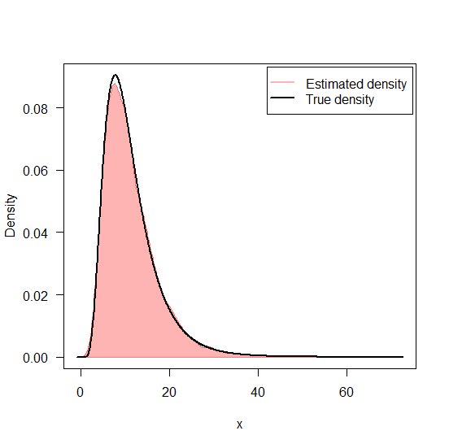

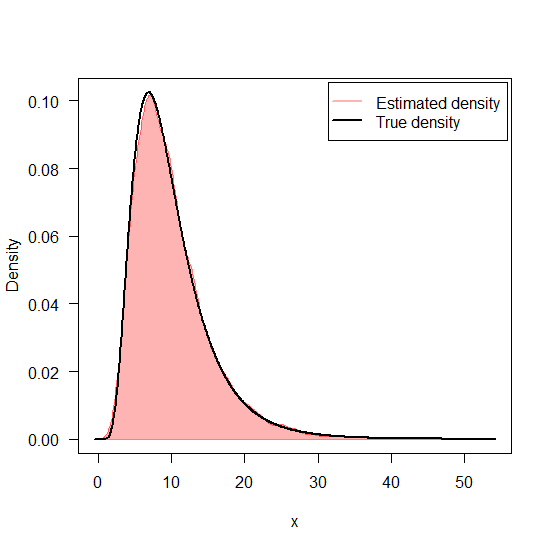

```r
R> mu1 = log(10); sigma1= sqrt(theta^2)  # log mean and log variance for mod1
R> mu2 = log(10)-0.5*theta^2 ; sigma2 = sqrt(theta^2) # log mean and log variance for mod2
R> AppdensI <- dsde1d(mod1, at = 1)
R> AppdensS <- dsde1d(mod2, at = 1)
R> plot(AppdensI , dens = function(x) dlnorm(x,meanlog=mu1,sdlog = sigma1))
R> plot(AppdensS , dens = function(x) dlnorm(x,meanlog=mu2,sdlog = sigma2))
```

In Figure 2, we present the flow of trajectories, the mean path (red lines) of solution of and , with their empirical $95\%$ confidence bands, that is to say from the $2.5th$ to the $97.5th$ percentile for each observation at time $t$ (blue lines):

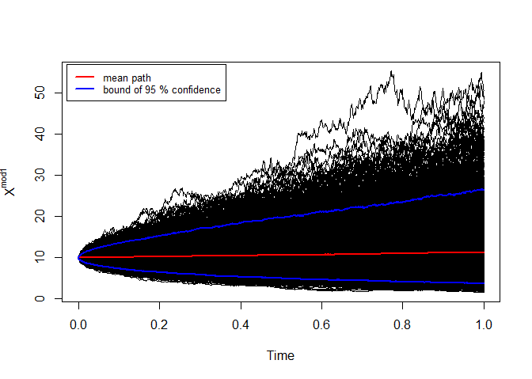

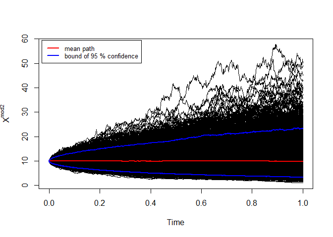

```r
R> ## Ito
R> plot(mod1,ylab=expression(X^mod1))
R> lines(time(mod1),apply(mod1$X,1,mean),col=2,lwd=2)
R> lines(time(mod1),apply(mod1$X,1,bconfint,level=0.95)[1,],col=4,lwd=2)
R> lines(time(mod1),apply(mod1$X,1,bconfint,level=0.95)[2,],col=4,lwd=2)
R> legend("topleft",c("mean path",paste("bound of", 95,"% confidence")),inset = .01,col=c(2,4),lwd=2,cex=0.8)
R> ## Stratonovich
R> plot(mod2,ylab=expression(X^mod2))
R> lines(time(mod2),apply(mod2$X,1,mean),col=2,lwd=2)
R> lines(time(mod2),apply(mod2$X,1,bconfint,level=0.95)[1,],col=4,lwd=2)
R> lines(time(mod2),apply(mod2$X,1,bconfint,level=0.95)[2,],col=4,lwd=2)
R> legend("topleft",c("mean path",paste("bound of",95,"% confidence")),col=c(2,4),inset =.01,lwd=2,cex=0.8)
```

Return to snssde1d()

# `snssde2d()`

The following $2$-dimensional SDE’s with a vector of drift and matrix of diffusion coefficients:

Ito form:
$$\begin{equation}\label{eq:09}
\begin{cases}
dX_t = f_{x}(t,X_{t},Y_{t}) dt + g_{x}(t,X_{t},Y_{t}) dW_{1,t}\\
dY_t = f_{y}(t,X_{t},Y_{t}) dt + g_{y}(t,X_{t},Y_{t}) dW_{2,t}
\end{cases}
\end{equation}$$

Stratonovich form:
$$\begin{equation}\label{eq:10}
\begin{cases}
dX_t = f_{x}(t,X_{t},Y_{t}) dt + g_{x}(t,X_{t},Y_{t}) \circ dW_{1,t}\\
dY_t = f_{y}(t,X_{t},Y_{t}) dt + g_{y}(t,X_{t},Y_{t}) \circ dW_{2,t}
\end{cases}
\end{equation}$$
where $(W_{1,t}, W_{2,t})$ are a two independent standard Wiener process if `corr = NULL`. To simulate $2d$ models using `snssde2d()` function we need to specify:

- The `drift` (2d) and `diffusion` (2d) coefficients as R expressions that depend on the state variable `x`, `y` and time variable `t`.
- `corr` the correlation structure of two standard Wiener process $(W_{1,t},W_{2,t})$; must be a real symmetric positive-definite square matrix of dimension $2$ (default: `corr=NULL`).
- The number of simulation steps `N` (default: `N=1000`).
- The number of the solution trajectories to be simulated by `M` (default: `M=1`).
- The initial conditions `t0`, `x0` and end time `T` (default: `t0=0`, `x0=c(0,0)` and `T=1`).
- The integration step size `Dt` (default: `Dt=(T-t0)/N`).
- The choice of process types by the argument `type="ito"` for Ito or `type="str"` for Stratonovich (default `type="ito"`).
- The numerical method to be used by `method` (default `method="euler"`).

## Ornstein-Uhlenbeck process and its integral

The Ornstein-Uhlenbeck (OU) process has a long history in physics. Introduced in essence by Langevin in his famous 1908 paper on Brownian motion, the process received a more thorough mathematical examination several decades later by Uhlenbeck and Ornstein (1930). The OU process is understood here to be the univariate continuous Markov process $X_t$. In mathematical terms, the equation is written as an Ito equation:
$$\begin{equation}\label{eq016}
dX_t = -\frac{1}{\mu} X_t dt + \sqrt{\sigma} dW_t,\quad X_{0}=x_{0}
\end{equation}$$
In these equations, $\mu$ and $\sigma$ are positive constants called, respectively, the relaxation time and the diffusion constant. The time integral of the OU process $X_t$ (or indeed of any process $X_t$) is defined to be the process $Y_t$ that satisfies:
$$\begin{equation}\label{eq017}
Y_{t} = Y_{0}+\int X_{t} dt \Leftrightarrow dY_t = X_{t} dt ,\quad Y_{0}=y_{0}
\end{equation}$$
$Y_t$ is not itself a Markov process; however, $X_t$ and $Y_t$ together comprise a bivariate continuous Markov process. We wish to find the solutions $X_t$ and $Y_t$ to the coupled time-evolution equations:
$$\begin{equation}\label{eq018}
\begin{cases}
dX_t = -\frac{1}{\mu} X_t dt + \sqrt{\sigma} dW_t\\
dY_t = X_{t} dt
\end{cases}
\end{equation}$$

We simulate a flow of $1000$ trajectories of $(X_{t},Y_{t})$, with integration step size $\Delta t = 0.01$, and using second Milstein method.

```r
R> set.seed(1234, kind = "L'Ecuyer-CMRG")
R> x0=5;y0=0
R> mu=3;sigma=0.5
R> fx <- expression(-(x/mu),x)
R> gx <- expression(sqrt(sigma),0)
R> mod2d <- snssde2d(drift=fx,diffusion=gx,Dt=0.01,M=1000,x0=c(x0,y0),method="smilstein")
R> mod2d
```

```
Itô Sde 2D:
    | dX(t) = -(X(t)/mu) * dt + sqrt(sigma) * dW1(t)
    | dY(t) = X(t) * dt + 0 * dW2(t)
Method:
    | Second-order Milstein scheme
Summary:
    | Size of process   | N  = 1001.
    | Number of simulation  | M  = 1000.
    | Initial values    | (x0,y0) = (5,0).
    | Time of process   | t in [0,10].
    | Discretization    | Dt = 0.01.
```

The summary of the results of `mod2d` at time $t=10$ of class `snssde2d()` is given by:

```r
R> summary(mod2d, at = 10)
```

[output not shown]

For plotting in time (or in plane) using the command `plot` (`plot2d`), the results of the simulation are shown in Figure 3.

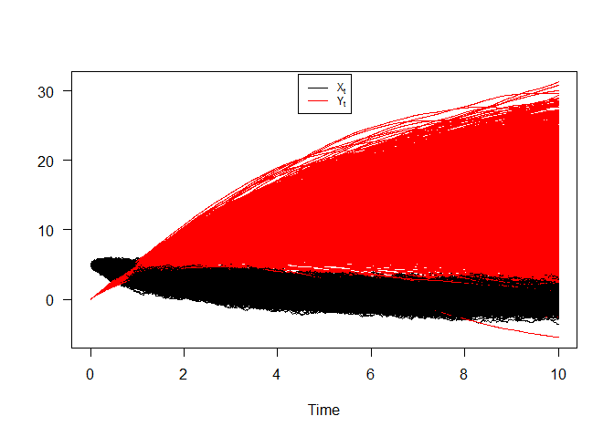

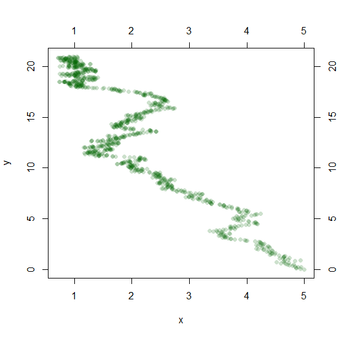

```r
R> ## in time
R> plot(mod2d)
R> ## in plane (O,X,Y)
R> plot2d(mod2d,type="n")
R> points2d(mod2d,col=rgb(0,100,0,50,maxColorValue=255), pch=16)
```

Hence we can just make use of the `rsde2d()` function to build our random number for $(X_{t},Y_{t})$ at time $t = 10$.

```r
R> out <- rsde2d(object = mod2d, at = 10)
R> head(out,n=3)
```

```
        x       y
1 0.32480 12.2224
2 0.91370  9.3092
3 0.49834 14.4406
```

The density of $X_t$ and $Y_t$ at time $t=10$ are reported using `dsde2d()` function, see e.g. Figure 4: the marginal density of $X_t$ and $Y_t$ at time $t=10$. For plotted in (x, y)-space with `dim = 2`. A `contour` and `image` plot of density obtained from a realization of system $(X_{t},Y_{t})$ at time `t=10`, see:

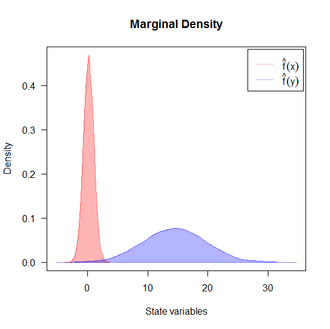

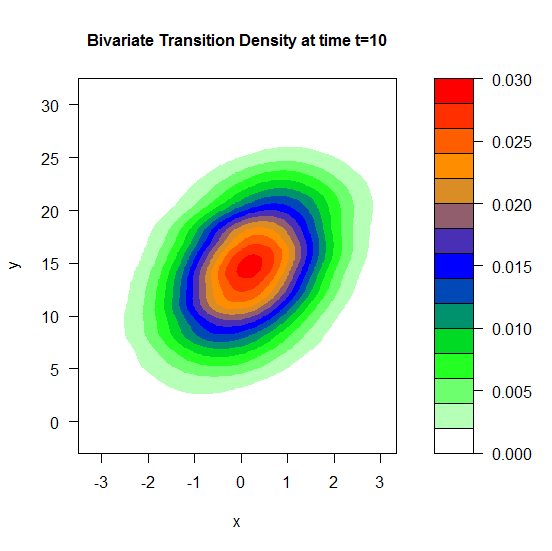

```r
R> ## the marginal density
R> denM <- dsde2d(mod2d,pdf="M",at =10)
R> plot(denM, main="Marginal Density")
R> ## the Joint density
R> denJ <- dsde2d(mod2d, pdf="J", n=100,at =10)
R> plot(denJ,display="contour",main="Bivariate Transition Density at time t=10")
```

A $3$D plot of the transition density at $t=10$ obtained with:

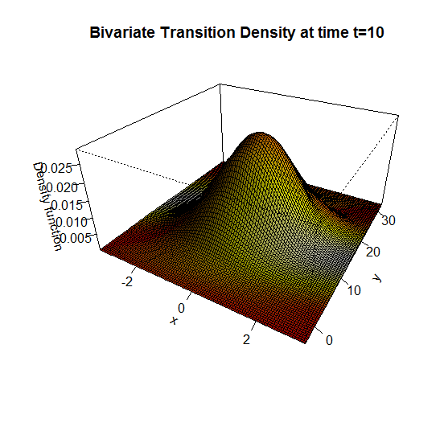

Marginal and Joint density at time t=10

```r
R> plot(denJ,display="persp",main="Bivariate Transition Density at time t=10")
```

We approximate the bivariate transition density over the set transition horizons $t\in [1,10]$ by $\Delta t = 0.005$ using the code:

```r
R> for (i in seq(1,10,by=0.005)){
+ plot(dsde2d(mod2d, at = i,n=100),display="contour",main=paste0('Transition Density \n t = ',i))
+ }
```

Return to snssde2d()

## The stochastic Van-der-Pol equation

The Van der Pol (1922) equation is an ordinary differential equation that can be derived from the Rayleigh differential equation by differentiating and setting $\dot{x}=y$, see Naess and Hegstad (1994); Leung (1995) and for more complex dynamics in Van-der-Pol equation see Jing et al. (2006). It is an equation describing self-sustaining oscillations in which energy is fed into small oscillations and removed from large oscillations. This equation arises in the study of circuits containing vacuum tubes and is given by:
$$\begin{equation}\label{eq:12}
\ddot{X}-\mu (1-X^{2}) \dot{X} + X = 0
\end{equation}$$
where $x$ is the position coordinate (which is a function of the time $t$), and $\mu$ is a scalar parameter indicating the nonlinearity and the strength of the damping, to simulate the deterministic equation see Grayling (2014) for more details. Consider stochastic perturbations of the Van-der-Pol equation, and random excitation force of such systems by White noise $\xi_{t}$, with delta-type correlation function $\text{E}(\xi_{t}\xi_{t+h})=2\sigma \delta (h)$
$$\begin{equation}\label{eq:13}
\ddot{X}-\mu (1-X^{2}) \dot{X} + X = \xi_{t},
\end{equation}$$
where $\mu > 0$ . It’s solution cannot be obtained in terms of elementary functions, even in the phase plane. The White noise $\xi_{t}$ is formally derivative of the Wiener process $W_{t}$. The representation of a system of two first order equations follows the same idea as in the deterministic case by letting $\dot{x}=y$, from physical equation we get the above system:
$$\begin{equation}\label{eq:14}
\begin{cases}
\dot{X} = Y \\
\dot{Y} = \mu \left(1-X^{2}\right) Y - X + \xi_{t}
\end{cases}
\end{equation}$$
The system can mathematically explain by a Stratonovitch equations:
$$\begin{equation}\label{eq:15}
\begin{cases}
dX_{t} = Y_{t} dt \\
dY_{t} = \left(\mu (1-X^{2}_{t}) Y_{t} - X_{t}\right) dt + 2 \sigma \circ dW_{2,t}
\end{cases}
\end{equation}$$

Implemente in R as follows, with integration step size $\Delta t = 0.01$ and using stochastic Runge-Kutta methods 1-stage.

```r
R> set.seed(1234, kind = "L'Ecuyer-CMRG")
R> mu = 4; sigma=0.1
R> fx <- expression( y ,  (mu*( 1-x^2 )* y - x))
R> gx <- expression( 0 ,2*sigma)
R> mod2d <- snssde2d(drift=fx,diffusion=gx,N=10000,Dt=0.01,type="str",method="rk1")
```

For plotting (back in time) using the command `plot`, and `plot2d` in plane the results of the simulation are shown in Figure 6.

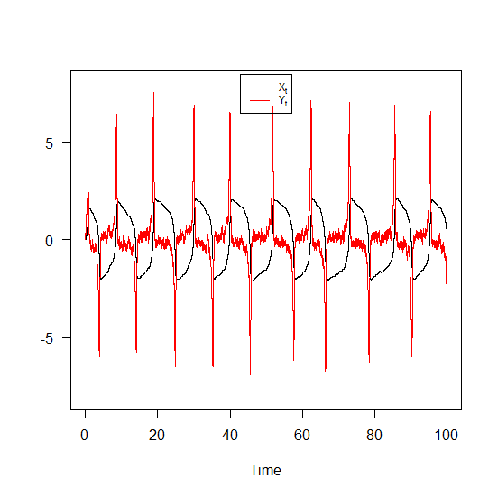

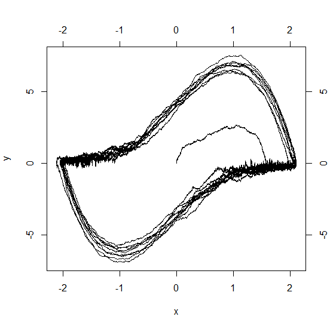

```r
R> plot(mod2d,ylim=c(-8,8))   ## back in time
R> plot2d(mod2d)              ## in plane (O,X,Y)
```

Return to snssde2d()

## The Heston Model

Consider a system of stochastic differential equations:

$$\begin{equation}\label{eq:115}
\begin{cases}
dX_{t} = \mu X_{t} dt + X_{t}\sqrt{Y_{t}} dB_{1,t}\\
dY_{t} = \nu (\theta-Y_{t}) dt + \sigma \sqrt{Y_{t}} dB_{2,t}
\end{cases}
\end{equation}$$

Conditions to ensure positiveness of the volatility process are that $2\nu \theta > \sigma^2$, and the two Brownian motions $(B_{1,t},B_{2,t})$ are correlated. $\Sigma$ to describe the correlation structure, for example:
$$\Sigma=
\begin{pmatrix}
1 & 0.3 \\
0.3 & 2
\end{pmatrix}$$

```r
R> set.seed(1234, kind = "L'Ecuyer-CMRG")
R> mu = 1.2; sigma=0.1;nu=2;theta=0.5
R> fx <- expression( mu*x ,nu*(theta-y))
R> gx <- expression( x*sqrt(y) ,sigma*sqrt(y))
R> Sigma <- matrix(c(1,0.3,0.3,2),nrow=2,ncol=2) # correlation matrix
R> HM <- snssde2d(drift=fx,diffusion=gx,Dt=0.001,x0=c(100,1),corr=Sigma,M=1000)
R> HM
```

```
Itô Sde 2D:
    | dX(t) = mu * X(t) * dt + X(t) * sqrt(Y(t)) * dB1(t)
    | dY(t) = nu * (theta - Y(t)) * dt + sigma * sqrt(Y(t)) * dB2(t)
    | Correlation structure:
             1.0 0.3
             0.3 2.0
Method:
    | Euler scheme with order 0.5
Summary:
    | Size of process   | N  = 1001.
    | Number of simulation  | M  = 1000.
    | Initial values    | (x0,y0) = (100,1).
    | Time of process   | t in [0,1].
    | Discretization    | Dt = 0.001.
```

Hence we can just make use of the `rsde2d()` function to build our random number for $(X_{t},Y_{t})$ at time $t = 1$.

```r
R> out <- rsde2d(object = HM, at = 1)
R> head(out,n=3)
```

```
       x       y
1 181.42 0.56526
2 137.85 0.52612
3 243.57 0.62700
```

The density of $X_t$ and $Y_t$ at time $t=1$ are reported using `dsde2d()` function. See:

```r
R> denJ <- dsde2d(HM,pdf="J",at =1,lims=c(-100,900,0.4,0.75))
R> plot(denJ,display="contour",main="Bivariate Transition Density at time t=10")
R> plot(denJ,display="persp",main="Bivariate Transition Density at time t=10")
```

[output not shown]

Return to snssde2d()

# `snssde3d()`

The following $3$-dimensional SDE’s with a vector of drift and matrix of diffusion coefficients:

Ito form:
$$\begin{equation}\label{eq17}
\begin{cases}
dX_t = f_{x}(t,X_{t},Y_{t},Z_{t}) dt + g_{x}(t,X_{t},Y_{t},Z_{t}) dW_{1,t}\\
dY_t = f_{y}(t,X_{t},Y_{t},Z_{t}) dt + g_{y}(t,X_{t},Y_{t},Z_{t}) dW_{2,t}\\
dZ_t = f_{z}(t,X_{t},Y_{t},Z_{t}) dt + g_{z}(t,X_{t},Y_{t},Z_{t}) dW_{3,t}
\end{cases}
\end{equation}$$

Stratonovich form:
$$\begin{equation}\label{eq18}
\begin{cases}
dX_t = f_{x}(t,X_{t},Y_{t},Z_{t}) dt + g_{x}(t,X_{t},Y_{t},Z_{t}) \circ dW_{1,t}\\
dY_t = f_{y}(t,X_{t},Y_{t},Z_{t}) dt + g_{y}(t,X_{t},Y_{t},Z_{t}) \circ dW_{2,t}\\
dZ_t = f_{z}(t,X_{t},Y_{t},Z_{t}) dt + g_{z}(t,X_{t},Y_{t},Z_{t}) \circ dW_{3,t}
\end{cases}
\end{equation}$$
$(W_{1,t},W_{2,t},W_{3,t})$ are three independents standard Wiener process if `corr = NULL`. To simulate this system using `snssde3d()` function we need to specify:

- The `drift` (3d) and `diffusion` (3d) coefficients as R expressions that depend on the state variables `x`, `y` , `z` and time variable `t`.
- `corr` the correlation structure of three standard Wiener process $(W_{1,t},W_{2,t},W_{2,t})$; must be a real symmetric positive-definite square matrix of dimension $3$ (default: `corr=NULL`).
- The number of simulation steps `N` (default: `N=1000`).
- The number of the solution trajectories to be simulated by `M` (default: `M=1`).
- The initial conditions `t0`, `x0` and end time `T` (default: `t0=0`, `x0=c(0,0,0)` and `T=1`).
- The integration step size `Dt` (default: `Dt=(T-t0)/N`).
- The choice of process types by the argument `type="ito"` for Ito or `type="str"` for Stratonovich (default `type="ito"`).
- The numerical method to be used by `method` (default `method="euler"`).

## Basic example

Assume that we want to describe the following SDE’s (3D) in Ito form:
$$\begin{equation}\label{eq0166}
\begin{cases}
dX_t = 4 (-1-X_{t}) Y_{t} dt + 0.2 dW_{1,t}\\
dY_t = 4 (1-Y_{t}) X_{t} dt + 0.2 dW_{2,t}\\
dZ_t = 4 (1-Z_{t}) Y_{t} dt + 0.2 dW_{3,t}
\end{cases}
\end{equation}$$
with $(W_{1,t},W_{2,t},W_{3,t})$ are three indpendant standard Wiener process.

We simulate a flow of $1000$ trajectories, with integration step size $\Delta t = 0.001$.

```r
R> set.seed(1234, kind = "L'Ecuyer-CMRG")
R> fx <- expression(4*(-1-x)*y , 4*(1-y)*x , 4*(1-z)*y)
R> gx <- rep(expression(0.2),3)
R> mod3d <- snssde3d(x0=c(x=2,y=-2,z=-2),drift=fx,diffusion=gx,M=1000)
R> mod3d
```

```
Itô Sde 3D:
    | dX(t) = 4 * (-1 - X(t)) * Y(t) * dt + 0.2 * dW1(t)
    | dY(t) = 4 * (1 - Y(t)) * X(t) * dt + 0.2 * dW2(t)
    | dZ(t) = 4 * (1 - Z(t)) * Y(t) * dt + 0.2 * dW3(t)
Method:
    | Euler scheme with order 0.5
Summary:
    | Size of process   | N  = 1001.
    | Number of simulation  | M  = 1000.
    | Initial values    | (x0,y0,z0) = (2,-2,-2).
    | Time of process   | t in [0,1].
    | Discretization    | Dt = 0.001.
```

The following statistical measures (`S3 method`) for class `snssde3d()` can be approximated for the $(X_{t},Y_{t},Z_{t})$ process at any time $t$, for example `at=1`:

```r
R> s = 1
R> mean(mod3d, at = s)
R> moment(mod3d, at = s , center = TRUE , order = 2) ## variance
R> Median(mod3d, at = s)
R> Mode(mod3d, at = s)
R> quantile(mod3d , at = s)
R> kurtosis(mod3d , at = s)
R> skewness(mod3d , at = s)
R> cv(mod3d , at = s )
R> min(mod3d , at = s)
R> max(mod3d , at = s)
R> moment(mod3d, at = s , center= TRUE , order = 4)
R> moment(mod3d, at = s , center= FALSE , order = 4)
```

The summary of the results of `mod3d` at time $t=1$ of class `snssde3d()` is given by:

```r
R> summary(mod3d, at = t)
```

[output not shown]

For plotting (back in time) using the command `plot`, and `plot3D` in space the results of the simulation are shown in Figure 7.

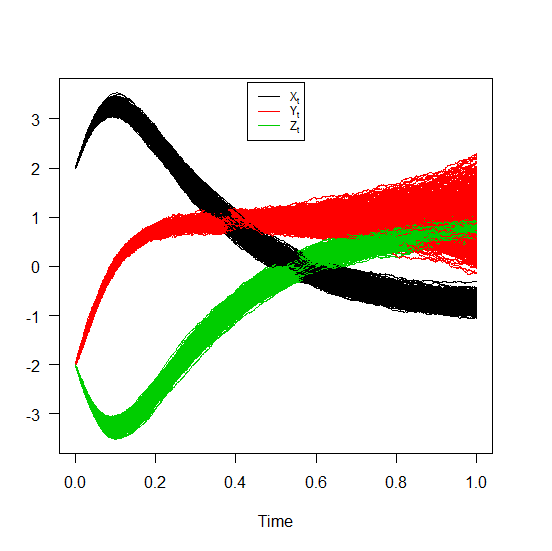

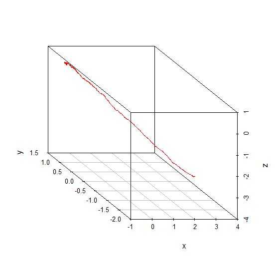

```r
R> plot(mod3d,union = TRUE)         ## back in time
R> plot3D(mod3d,display="persp")    ## in space (O,X,Y,Z)
```

Hence we can just make use of the `rsde3d()` function to build our random number for $(X_{t},Y_{t},Z_{t})$ at time $t = 1$.

```r
R> out <- rsde3d(object = mod3d, at = 1)
R> head(out,n=3)
```

```
         x       y       z
1 -0.73929 0.65851 0.64650
2 -0.63795 0.41731 0.79531
3 -0.80249 1.16501 0.83721
```

For each SDE type and for each numerical scheme, the marginal density of $X_t$, $Y_t$ and $Z_t$ at time $t=1$ are reported using `dsde3d()` function, see e.g. Figure 8.

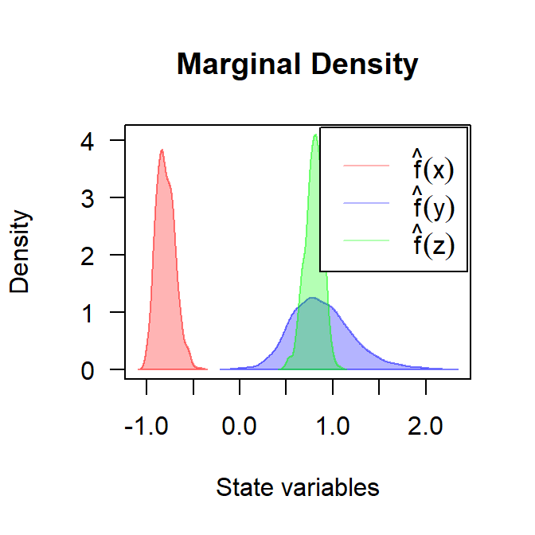

Marginal density of $X_t$, $Y_t$ and $Z_t$ at time $t=1$

```r
R> den <- dsde3d(mod3d,pdf="M",at =1)
R> plot(den, main="Marginal Density")
```

For an approximate joint transition density for $(X_t,Y_t,Z_t)$ (for more details, see package sm or ks.)

```r
R> denJ <- dsde3d(mod3d,pdf="J")
R> plot(denJ,display="rgl")
```

Return to snssde3d()

## Attractive model for 3D diffusion processes

If we assume that $U_w( x , y , z , t )$, $V_w( x , y , z , t )$ and $S_w( x , y , z , t )$ are neglected and the dispersion coefficient $D( x , y , z )$ is constant. A system becomes (see Boukhetala,1996):
$$\begin{eqnarray}\label{eq19}
% \nonumber to remove numbering (before each equation)
\begin{cases}
dX_t = \left(\frac{-K X_{t}}{\sqrt{X^{2}_{t} + Y^{2}_{t} + Z^{2}_{t}}}\right) dt + \sigma dW_{1,t} \nonumber\\
dY_t = \left(\frac{-K Y_{t}}{\sqrt{X^{2}_{t} + Y^{2}_{t} + Z^{2}_{t}}}\right) dt + \sigma dW_{2,t} \\
dZ_t = \left(\frac{-K Z_{t}}{\sqrt{X^{2}_{t} + Y^{2}_{t} + Z^{2}_{t}}}\right) dt + \sigma dW_{3,t} \nonumber
\end{cases}
\end{eqnarray}$$
with initial conditions $(X_{0},Y_{0},Z_{0})=(1,1,1)$, by specifying the drift and diffusion coefficients of three processes $X_{t}$, $Y_{t}$ and $Z_{t}$ as R expressions which depends on the three state variables `(x,y,z)` and time variable `t`, with integration step size `Dt=0.0001`.

```r
R> set.seed(1234, kind = "L'Ecuyer-CMRG")
R> K = 4; s = 1; sigma = 0.2
R> fx <- expression( (-K*x/sqrt(x^2+y^2+z^2)) , (-K*y/sqrt(x^2+y^2+z^2)) , (-K*z/sqrt(x^2+y^2+z^2)) )
R> gx <- rep(expression(sigma),3)
R> mod3d <- snssde3d(drift=fx,diffusion=gx,N=10000,x0=c(x=1,y=1,z=1))
```

The results of simulation (3D) are shown in Figure 9:

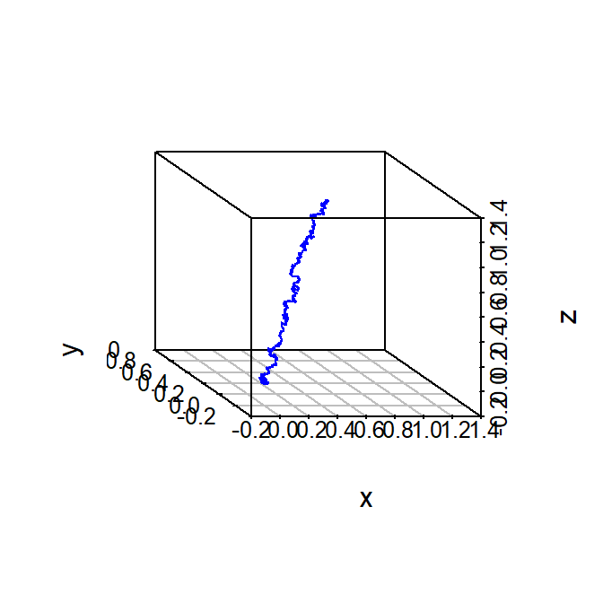

Attractive model for 3D diffusion processes

```r
R> plot3D(mod3d,display="persp",col="blue")
```

Return to snssde3d()

## Transformation of an SDE one-dimensional

Next is an example of one-dimensional SDE driven by three correlated Wiener process ($B_{1,t}$,$B_{2,t}$,$B_{3,t}$), as follows:
$$\begin{equation}\label{eq20}
dX_{t} = B_{1,t} dt + B_{2,t} dB_{3,t}
\end{equation}$$
with:
$$\Sigma=
\begin{pmatrix}
1 & 0.2 &0.5\\
0.2 & 1 & -0.7 \\
0.5 &-0.7&1
\end{pmatrix}$$
To simulate the solution of the process $X_t$, we make a transformation to a system of three equations as follows:
$$\begin{eqnarray}\label{eq21}
\begin{cases}
% \nonumber to remove numbering (before each equation)
dX_t = Y_{t} dt + Z_{t} dB_{3,t} \nonumber\\
dY_t = dB_{1,t} \\
dZ_t = dB_{2,t} \nonumber
\end{cases}
\end{eqnarray}$$
run by calling the function `snssde3d()` to produce a simulation of the solution, with $\mu = 1$ and $\sigma = 1$.

```r
R> set.seed(1234, kind = "L'Ecuyer-CMRG")
R> fx <- expression(y,0,0)
R> gx <- expression(z,1,1)
R> Sigma <-matrix(c(1,0.2,0.5,0.2,1,-0.7,0.5,-0.7,1),nrow=3,ncol=3)
R> modtra <- snssde3d(drift=fx,diffusion=gx,M=1000,corr=Sigma)
R> modtra
```

```
Itô Sde 3D:
    | dX(t) = Y(t) * dt + Z(t) * dB1(t)
    | dY(t) = 0 * dt + 1 * dB2(t)
    | dZ(t) = 0 * dt + 1 * dB3(t)
    | Correlation structure:
             1.0  0.2  0.5
             0.2  1.0 -0.7
             0.5 -0.7  1.0
Method:
    | Euler scheme with order 0.5
Summary:
    | Size of process   | N  = 1001.
    | Number of simulation  | M  = 1000.
    | Initial values    | (x0,y0,z0) = (0,0,0).
    | Time of process   | t in [0,1].
    | Discretization    | Dt = 0.001.
```

The histogram and kernel density of $X_t$ at time $t=1$ are reported using `rsde3d()` function, and we calculate emprical variance-covariance matrix $C(s,t)=\text{Cov}(X_{s},X_{t})$, see e.g. Figure 10.

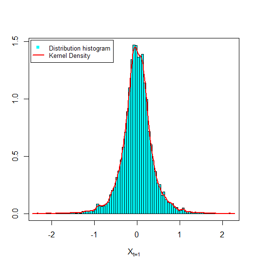

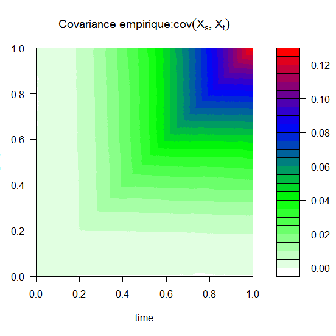

```r
R> X <- rsde3d(modtra,at=1)$x
R> MASS::truehist(X,xlab = expression(X[t==1]));box()
R> lines(density(X),col="red",lwd=2)
R> legend("topleft",c("Distribution histogram","Kernel Density"),inset =.01,pch=c(15,NA),lty=c(NA,1),col=c("cyan","red"), lwd=2,cex=0.8)
R> ## Cov-Matrix
R> color.palette=colorRampPalette(c('white','green','blue','red'))
R> filled.contour(time(modtra), time(modtra), cov(t(modtra$X)), color.palette=color.palette,plot.title = title(main = expression(paste("Covariance empirique:",cov(X[s],X[t]))),xlab = "time", ylab = "time"),key.title = title(main = ""))
```

Return to snssde3d()

# Further reading

1. `snssdekd()` & `dsdekd()` & `rsdekd()`- Monte-Carlo Simulation and Analysis of Stochastic Differential Equations.
2. `bridgesdekd()` & `dsdekd()` & `rsdekd()` - Constructs and Analysis of Bridges Stochastic Differential Equations.
3. `fptsdekd()` & `dfptsdekd()` - Monte-Carlo Simulation and Kernel Density Estimation of First passage time.
4. `MCM.sde()` & `MEM.sde()` - Parallel Monte-Carlo and Moment Equations for SDEs.
5. `TEX.sde()` - Converting Sim.DiffProc Objects to LaTeX.
6. `fitsde()` - Parametric Estimation of 1-D Stochastic Differential Equation.

# References

1. Boukhetala K (1996). Modelling and Simulation of a Dispersion Pollutant with Attractive Centre, volume 3, pp. 245-252. Computer Methods and Water Resources, Computational Mechanics Publications, Boston, USA.
2. Guidoum AC, Boukhetala K (2020). “Performing Parallel Monte Carlo and Moment Equations Methods for Itô and Stratonovich Stochastic Differential Systems: R Package Sim.DiffProc”. Journal of Statistical Software, 96(2), 1–82. https://doi.org/10.18637/jss.v096.i02
[^1]: Department of Probabilities & Statistics, Faculty of Mathematics, University of Science and Technology Houari Boumediene, BP 32 El-Alia, U.S.T.H.B, Algeria, E-mail (acguidoum@usthb.dz)
[^2]: Faculty of Mathematics, University of Science and Technology Houari Boumediene, BP 32 El-Alia, U.S.T.H.B, Algeria, E-mail (kboukhetala@usthb.dz)
[^3]: The equivalently of $X_{t}^{\text{mod1}}$ the following Stratonovich SDE: $dX_{t} = \theta X_{t} \circ dW_{t}$.